# Capstone: LDA

Andrew Knittle

Generated on 2021-07-31

# Method

[Linear Discriminatory Analysis (LDA) focuses on maximizing the separability among known categories,](https://www.youtube.com/watch?v=azXCzI57Yfc&t=641s&ab_channel=StatQuestwithJoshStarmer) in this case it’s positive and negative cancer results. This is done via a “cut”, or plain, to create the separation. [LDA starts by creating a new axis that satisfies two criteria](https://youtu.be/azXCzI57Yfc?t=447):

- 1. Maximize the distance between means of each category.
- 2. Minimize the variation, or “scatter” $s^2$, within each category.

This can be represented as $\frac{(\mu_1-\mu_2)^2}{s_1^2 + s_2^2}$. A large numerator and a small denominator is ideal. Once this new axis is created points are then projected onto it. This is done on each feature, where [“the linear combination of predictor variables that are used to form the LDA decision rule.”](http://www.sthda.com/english/articles/36-classification-methods-essentials/146-discriminant-analysis-essentials-in-r/) In other words these variables are used to find the best linear combination of them to help best distinguish data across the two groups. [For each individual LDA finds the probability of belonging to the different groups, and whichever probability is the highest per group that individual is assigned to said group.](http://www.sthda.com/english/articles/36-classification-methods-essentials/146-discriminant-analysis-essentials-in-r/)

An important quirk about LDA is that it only works on continuous independent variables because a categorical variable has no mean or variation, it’s either one thing or another. This is perfect for the amount of chemicals detected as they are all continuous features.

It functions similarly to Principle Component Analysis (PCA) by creating new axes and reducing dimensions. PCA does this by looking at the variation of features while LDA looks at variation between categories and maximize their separation.

# Performance

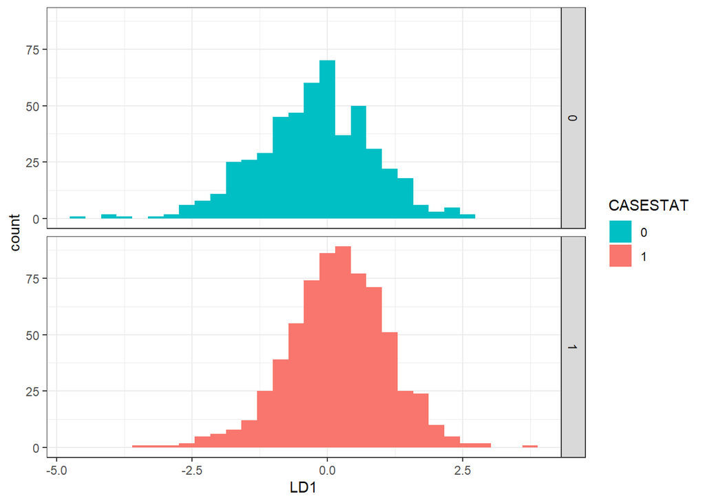

Model Building

| Avg. Training Error | Avg. Validation Error |
| --- | --- |
| 0.3841518 | 0.4186441 |

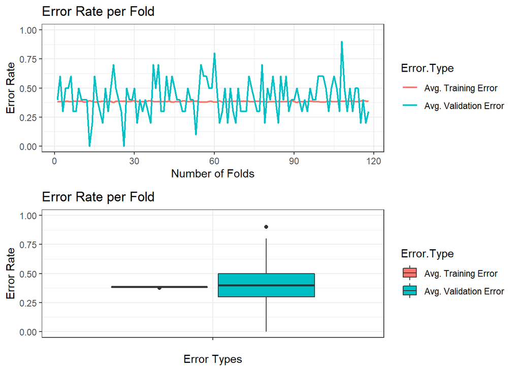

Model Building

|  | Observed NO | Observed YES |
| --- | --- | --- |
| Predicted NO | 150 | 136 |
| Predicted YES | 358 | 536 |

| Error Rate | False Positive Rate (Fall-Out) | False Negative Rate (Miss Rate) | True Positive Rate (Sensitivity) | True Negative Rate (Specificity) | Precision (PPV) | Negative Predictive Value (NPV) |
| --- | --- | --- | --- | --- | --- | --- |
| 0.4186441 | 0.7047244 | 0.202381 | 0.797619 | 0.2952756 | 0.5995526 | 0.5244755 |

# Conclusion

We can see from the LDA histogram plot that there is a lot of cross over which is the opposite of what we should be seeing if this is model was good at discriminating between groups.